# lab5

Jonah Librande

```python
import pickle
import scipy
import matplotlib.pyplot as plt
import numpy as np
```

We selected the LHC Higgs data for our analysis. The first notable feature about it is that the training data is simulated via the Monte Carlo method -- our noble, just, virtuous, etc. TA produced them, in fact. This is a qualitative difference to keep in mind as compared with actual data -- the simulated data may have more regularity to it, or be missing features of the real data.

The actual data is taken as follows. The Large Hadron Collider (henceforth, LHC) is used to collide a pair of protons at very large energies. About the collision point, the ATLAS detector is positioned. It is an assembly surrounding the collision point, encompassing almost all solid angles about the detector. For suitably small pseudorapidity (defined below), the detector has superconducting components which allow for the tracking of charged products of the collision. Electromagnetic calorimeters allow for the measurement of the energy of the collision products. Additionally, there exists several noise filters implemented in the hardware and software components of the detector which help assure that the reported events are actual interesting collision products.

The events in question are "jets" of particles which result from a collision. Each will contain one or more particles, and so at several points in the below analysis, the particles in a jet are enumerated in order to define some of the attributes of a jet event.

```python
infile = open ("qcd_100000_pt_1000_1200.pkl",'rb')
ram = pickle.load(infile)
ranch = pickle.load(open("higgs_100000_pt_1000_1200.pkl",'rb'))
print(type(ranch))
print(ranch.keys())
```

```
<class 'pandas.core.frame.DataFrame'>
Index(['pt', 'eta', 'phi', 'mass', 'ee2', 'ee3', 'd2', 'angularity', 't1',
       't2', 't3', 't21', 't32', 'KtDeltaR'],
      dtype='object')
```

# Variable: pt

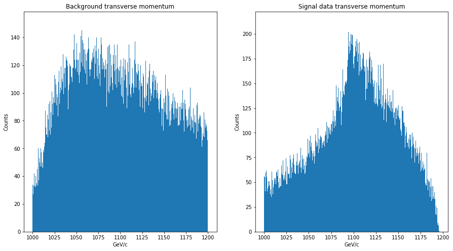

```python
fig, a = plt.subplots(1, 2, figsize = (15, 8))

a[0].hist(ram.get('pt'), bins = 1000)
a[0].set_title('Background transverse momentum')
a[0].set_ylabel('Counts')
a[0].set_xlabel('GeV/c')
a[1].hist(ranch.get('pt'), bins = 1000)
a[1].set_title('Signal data transverse momentum')
a[1].set_ylabel('Counts')
a[1].set_xlabel('GeV/c')

plt.show()
```

# Variable: eta

This is the pseudorapidity, or, a measure of the angle between the particle beam and the 3-momentum of the collision products. A larger magnitude pseudorapidity corresponds to the collision products more closely aligning with the beam, but this is a signed quantity: we have $\eta = 0$ when $\theta = \frac{\pi}{2}$, $\theta \to 0 \implies \eta \to \infty$, and $\theta \to \pi \implies \eta \to -\infty$. We see that pseudorapidity looks roughly normally distributed about 0 in both data sets, below. However, the signal data is more tightly clustered about 0.

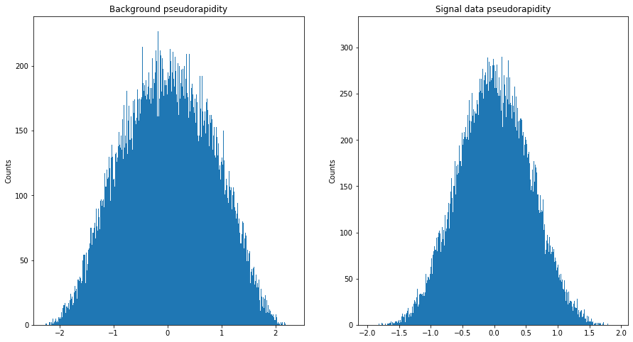

```python
fig, a = plt.subplots(1, 2, figsize = (15, 8))

a[0].hist(ram.get('eta'), bins = 1000)
a[0].set_title('Background pseudorapidity')
a[0].set_ylabel('Counts')
a[1].hist(ranch.get('eta'), bins = 1000)
a[1].set_title('Signal data pseudorapidity')
a[1].set_ylabel('Counts')

plt.show()
```

# Variable: phi

This is the azimuthal angle, the angle in the transverse plane between $p_T$ and the horizontal. It, along with pseudorapidity, can characterize the direction of a jet. It seems to be approximately uniformly distributed, in both data sets.

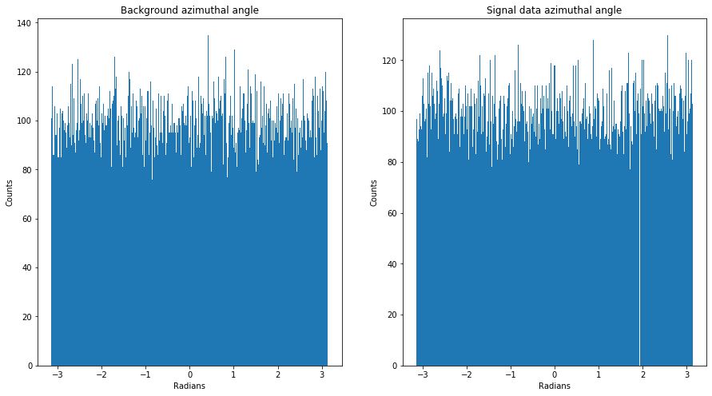

```python
fig, a = plt.subplots(1, 2, figsize = (15, 8))

a[0].hist(ram.get('phi'), bins = 1000)
a[0].set_title('Background azimuthal angle')
a[0].set_ylabel('Counts')
a[0].set_xlabel('Radians')
a[1].hist(ranch.get('phi'), bins = 1000)
a[1].set_title('Signal data azimuthal angle')
a[1].set_ylabel('Counts')
a[1].set_xlabel('Radians')

plt.show()
```

# Variable: mass

The invariant mass associated to the jet. This is the frame independent quantity $\sqrt{E^2 - p^2} = m$, which is a Lorentz scalar. This is rather sharply peaked, and if we recall the predicted Higgs mass is roughly 125 GeV/c^2, we see this is very close to the peak, in both cases. This reveals the horizontal axis to be GeV/c^2. The long upper tail of measured masses is fine - no one requires that these Higgs bosons be on shell, though it is vastly more likely they are than not. For signal data, we notice the peaking is extreme compared to the background. To demonstrate how extreme, note I have changed the vertical scaling on the signal data, but it still looks heavily peaked.

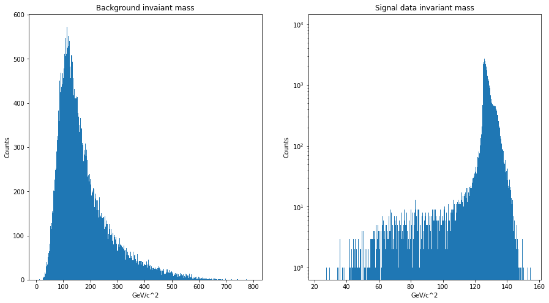

```python
fig, a = plt.subplots(1, 2, figsize = (15, 8))

a[0].hist(ram.get('mass'), bins = 1000)
a[0].set_title('Background invaiant mass')
a[0].set_ylabel('Counts')
a[0].set_xlabel('GeV/c^2')
a[1].hist(ranch.get('mass'), bins = 1000)
a[1].set_title('Signal data invariant mass')
a[1].set_ylabel('Counts')
a[1].set_xlabel('GeV/c^2')
a[1].set_yscale('log')

plt.show()
```

# Variable: ee2

This is a bit trickier. This refers to the two-point energy correlation function ratio of the jet; this is the sum $\sum_{i<j \in J} p_{T,i} p_{T,j} \Delta R_{ij} \frac{1}{p_{T,J}^2}$, where the subscripts enumerate particles of a jet $J$, and $\Delta R_{ij}$ is the "Euclidean angular distance" $R_{ij}^2 = (\eta_i - \eta_j)^2 + (\phi_i - \phi_j)^2$. A wider spread indicates a lot of energy in the center of mass frame, and it is less likely an event occurs with so much surplus energy in the background. Dividing by the overall transverse momentum of the jet further depresses the value of this variable. The difference between the background and signal data here is striking: the background mean is close to 0, but has a long tail towards larger values, while the signal data is much more clustered, with a very small tail.

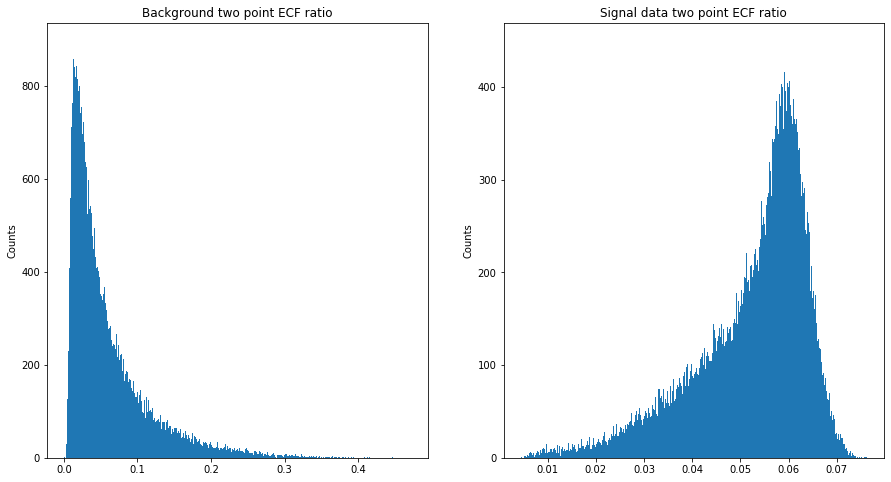

```python
fig, a = plt.subplots(1, 2, figsize = (15, 8))

a[0].hist(ram.get('ee2'), bins = 1000)
a[0].set_title('Background two point ECF ratio')
a[0].set_ylabel('Counts')
a[1].hist(ranch.get('ee2'), bins = 1000)
a[1].set_title('Signal data two point ECF ratio')
a[1].set_ylabel('Counts')

plt.show()
```

# Variable: ee3

As above, but now we examine the ECF $\sum_{i<j<k \in J} p_{T,i} p_{T,j} p_{T,k} \Delta R_{ij} \Delta R_{ik} \Delta R_{jk} \frac{1}{p_{T,J}^3}$. We expect this is more sharply peaked, and it is; if the likelihood of finding two particles in a jet with uncorrelated energies was low, it is even less likely for three, as two of the particles are more likely to be adjacent. We note the background is both more sharply peaked and has a longer tail than the signal. The signal is distinguished by a very short tale. Neither has a clearly recognizable distribution at a glance.

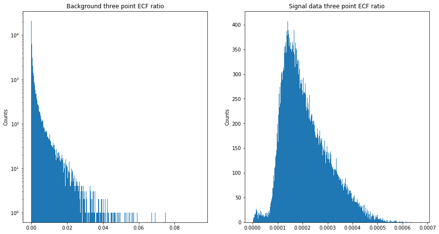

```python
fig, a = plt.subplots(1, 2, figsize = (15, 8))

a[0].hist(ram.get('ee3'), bins = 1000)
a[0].set_title('Background three point ECF ratio')
a[0].set_ylabel('Counts')
a[0].set_yscale('log')
a[1].hist(ranch.get('ee3'), bins = 1000)
a[1].set_title('Signal data three point ECF ratio')
a[1].set_ylabel('Counts')

plt.show()
```

# Variable: d2

This is the ratio ee3 / (ee2)^3. As before the signal data has a smaller tail than the background.

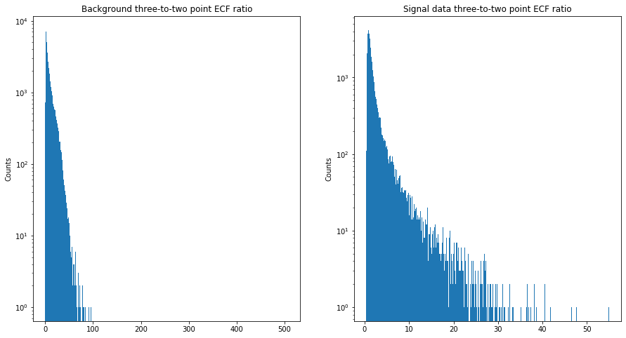

```python
fig, a = plt.subplots(1, 2, figsize = (15, 8))

a[0].hist(ram.get('d2'), bins = 1000)
a[0].set_title('Background three-to-two point ECF ratio')
a[0].set_ylabel('Counts')
a[0].set_yscale('log')
a[1].hist(ranch.get('d2'), bins = 1000)
a[1].set_title('Signal data three-to-two point ECF ratio')
a[1].set_ylabel('Counts')
a[1].set_yscale('log')

plt.show()
```

# Variable: anglularity

Angularity is denoted by $\tau_{-2}$ and defined by $\tau_{-2} = \frac{1}{m_J} \sum_{i \in J} E_i sin^{-2}(\theta_i)cos^3(\theta_i)$, where $J$ is a jet and $i$ enumerates particles in the jet. We see this is several times more sharply peaked for the signal than the background, and the tail is much more negligible than for the background, too.

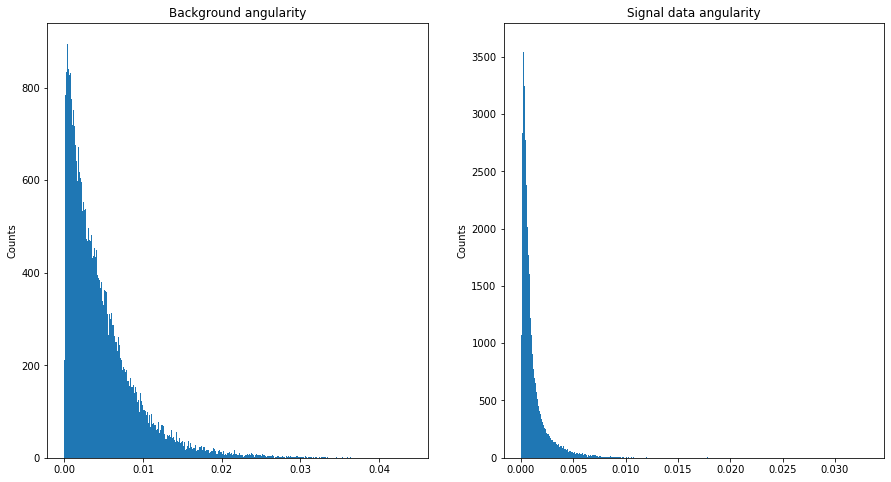

```python
fig, a = plt.subplots(1, 2, figsize = (15, 8))

a[0].hist(ram.get('angularity'), bins = 1000)
a[0].set_title('Background angularity')
a[0].set_ylabel('Counts')
a[1].hist(ranch.get('angularity'), bins = 1000)
a[1].set_title('Signal data angularity')
a[1].set_ylabel('Counts')

plt.show()
```

# Variable: t1

Okay, these variables are insane. It took me so much time to figure out what these dumb little t-variables are, so with great disgust I announce this one is called 1-subjettiness. Thaler and Tilberg introduced it (God smite them), and wrote about its utility for identifying collision products of large invariant mass from the QCD background - and the Higgs mass is nothing if not very large. I default to Thaler and Tilberg for a description of it: "N-subjettiness measures the degree to which radiation within a jet is aligned along N candidate subjet axes" (Thaler and Tilberg, "Maximizing Boosted Top Identification by Minimizing N-subjettiness," 2011). It involves a sum over the product of each individual particle's $p_T$ multiplied by the Euclidean distance in the $\eta$-$\phi$ plane to the nearest chosen axis, with some overall normalization.

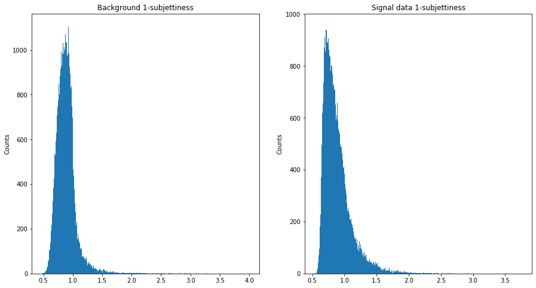

```python
fig, a = plt.subplots(1, 2, figsize = (15, 8))

a[0].hist(ram.get('t1'), bins = 1000)
a[0].set_title('Background 1-subjettiness')
a[0].set_ylabel('Counts')
a[1].hist(ranch.get('t1'), bins = 1000)
a[1].set_title('Signal data 1-subjettiness')
a[1].set_ylabel('Counts')

plt.show()
```

# Variable: t2

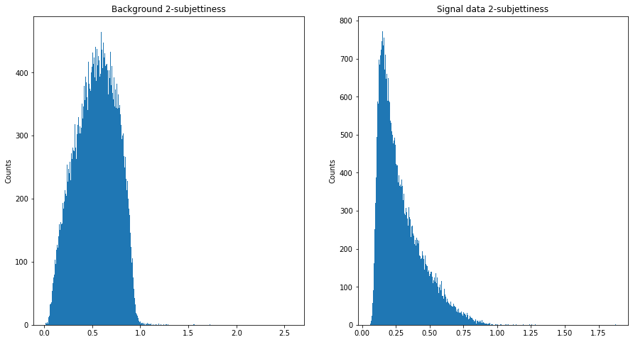

```python
fig, a = plt.subplots(1, 2, figsize = (15, 8))

a[0].hist(ram.get('t2'), bins = 1000)
a[0].set_title('Background 2-subjettiness')
a[0].set_ylabel('Counts')
a[1].hist(ranch.get('t2'), bins = 1000)
a[1].set_title('Signal data 2-subjettiness')
a[1].set_ylabel('Counts')

plt.show()
```

# Variable: t3

This is 3-subjettiness. Look above for an explanation of what it is. We expect the mean will be even moreso reduced by the addition of an extra axis compared to t2. In addition, the background has a distribution of just a large lump, while the signal is a much sharper peak with a long tail. The visual difference is striking.

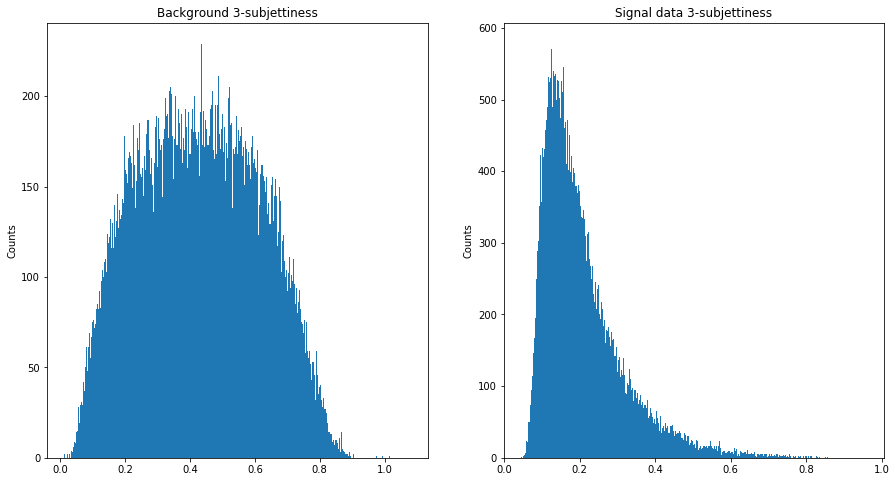

```python
fig, a = plt.subplots(1, 2, figsize = (15, 8))

a[0].hist(ram.get('t3'), bins = 1000)
a[0].set_title('Background 3-subjettiness')
a[0].set_ylabel('Counts')
a[1].hist(ranch.get('t3'), bins = 1000)
a[1].set_title('Signal data 3-subjettiness')
a[1].set_ylabel('Counts')

plt.show()
```

# Variable: t21

This is the ratio of subjettinesses t2 / t1 for a given jet. For both data sets the distributions have similar peaks and shapes, but the two distributions are almost mirror images of one another on the interval $[0, 1]$.

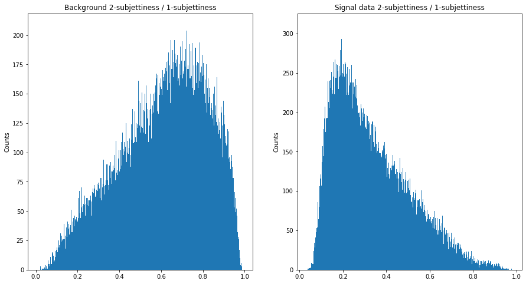

```python
fig, a = plt.subplots(1, 2, figsize = (15, 8))

a[0].hist(ram.get('t21'), bins = 1000)
a[0].set_title('Background 2-subjettiness / 1-subjettiness')
a[0].set_ylabel('Counts')
a[1].hist(ranch.get('t21'), bins = 1000)
a[1].set_title('Signal data 2-subjettiness / 1-subjettiness')
a[1].set_ylabel('Counts')

plt.show()
```

# Variable: t32

This is the ratio for a given jet of its variables t3 / t2. It looks approximately the same for both data sets; it appears to be minimally useful for discriminating from the background.

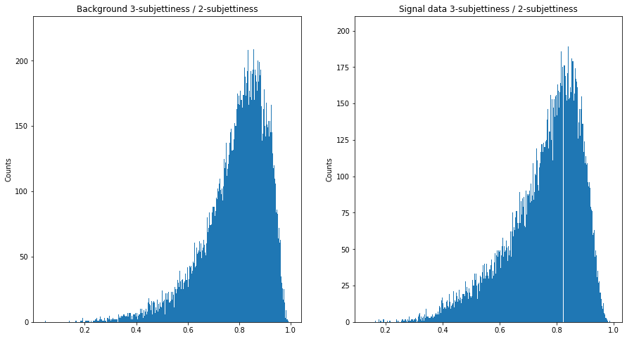

```python
fig, a = plt.subplots(1, 2, figsize = (15, 8))

a[0].hist(ram.get('t32'), bins = 2000)
a[0].set_title('Background 3-subjettiness / 2-subjettiness')
a[0].set_ylabel('Counts')
a[1].hist(ranch.get('t32'), bins = 2000)
a[1].set_title('Signal data 3-subjettiness / 2-subjettiness')
a[1].set_ylabel('Counts')

plt.show()
```

# Variable: KtDeltaR

This, I can find no resources on. Note that it appears to be a powerful discriminator between the background and signal: both distributions are sharply peaked, but the background is centered at zero, while the signal is mostly concentrated at about 0.25. Also note the existence of a small secondary peak about 0 in the signal.

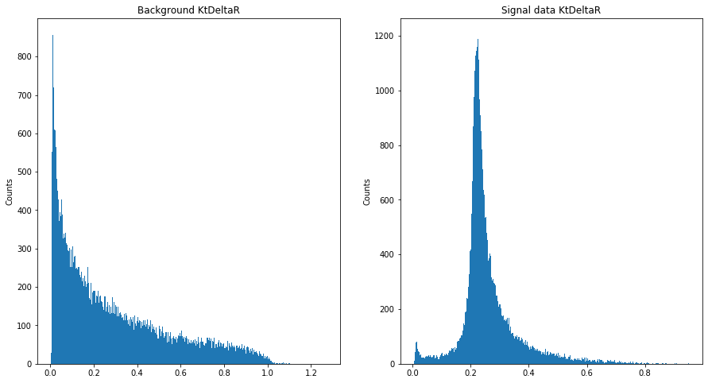

```python
fig, a = plt.subplots(1, 2, figsize = (15, 8))

a[0].hist(ram.get('KtDeltaR'), bins = 1000)
a[0].set_title('Background KtDeltaR')
a[0].set_ylabel('Counts')
a[1].hist(ranch.get('KtDeltaR'), bins = 1000)
a[1].set_title('Signal data KtDeltaR')
a[1].set_ylabel('Counts')

plt.show()
```